# alleleAtlas tutorial

Satoshi Aoki

2026-07-23

## 1 Aim of this package, alleleAtlas

The alleleAtlas is an R package for spatial interpolation of allele frequencies. This package uses Bayesian inference by R-INLA.

## 2 Installation

This package is not on CRAN because the depending package, R-INLA, is not on CRAN. So, you first have to get the method to install packages from GitHub. One way to do it is using devtools package. The following command installs devtools and alleleAtlas.

```r
install.packages("INLA",repos=c(getOption("repos"),INLA="https://inla.r-inla-download.org/R/stable"), dep=TRUE)
install.packages("devtools")
library(devtools)
devtools::install_github("alleleAtlas/Sa-to-shi-A-o-ki", upgrade="never")
```

The other depending packages are also necessary. The depending packages are: spatstat, s2, gridExtra, leaflet,leaflet.minicharts, parzer, fmesher, sf,spdep They are all on CRAN. Therefore, they can be installed using install.packages function.

## 3 How to use

First, please load the package by the following command:

```r
library(alleleAtlas)
```

### 3.1 Data preparation & Import

We need data of the sampling locations and alleles for the analysis. The next command imports example data included in this package.

```r
Edata<-readLines(system.file("extdata","Faguslocationdata.csv",package="alleleAtlas"),encoding="UTF-8")
```

The loaded data look like this.

```r
Edata
```

```
#>  [1] "140.3,42.6,cattttttacacatttgtatgaagcaacgtcttcgtcgataccatcggtagagcttgtaa…--ttttttttttccaaaatcaaaagagcgattaggttgaacaaataaaggatctcgagccatcttgttatcctagaatgcacataaaccgattaaattagctggaaaaagagagaataaagagtccgttgatcagtcttatctgtttccggggtatatatttatt------cttttcttactataatagcctgttttgaccgtatcgtactatgtgtta…
#>  [2] "140.4,41.7,cattttttacacatttgtatgaagcaacgtcttcgtcgataccatcggtagagcttgtaa…--ttttttttttccaaaatcaaaagagcgattaggttgaacaaataaaggatctcgagccatcttgttatcctagaatgcacataaaccgattaaattagctggaaaaagagagaataaagagtccgttgatcagtcttatctgtttccggggtatatatttatt------cttttcttactataatagcctgttttgaccgtatcgtactatgtgtta…
#>  [3] "140.2,41.6,cattttttacacatttgtatgaagcaacgtcttcgtcgataccatcggtagagcttgtaa…--ttttttttttccaaaatcaaaagagcgattaggttgaacaaataaaggatctcgagccatcttgttatcctagaatgcacataaaccgattaaattagctggaaaaagagagaataaagagtccgttgatcagtcttatctgtttccggggtatatatttatt------cttttcttactataatagcctgttttgaccgtatcgtactatgtgtta…
#>  [4] "140,40.6,cattttttacacatttgtatgaagcaacgtcttcgtcgataccatcggtagagcttgtaa…--ttttttttttccaaaatcaaaagagcgattaggttgaacaaataaaggatctcgagccatcttgttatcctagaatgcacataaaccgattaaattagctggaaaaagagagaataaagagtccgttgatcagtcttatctgtttccggggtatatatttatt------cttttcttactataatagcctgttttgaccgtatcgtactatgtgttatt…
#>  [5] "141,40,cattttttacacatttgtatgaagcaacgtcttcgtcgataccatcggtagagcttgtaa…--ttttttttttccaaaatcaaaagagcgattaggttgaacaaataaaggatctcgagccatcttgttatcctagaatgcacataaaccgattaaattagctggaaaaagagagaataaagagtccgttgatcagtcttatctgtttccggggtatatatttatt------cttttcttactataatagcctgttttgaccgtatcgtactatgtgttattta…
#>  [6] "141.5,39.6,cattttttacacatttgtatgaagcaacgtcttcgtcgataccatcggtagagcttgtaa…--ttttttttttccaaaatcaaaagagcgattaggttgaacaaataaaggatctcgagccatcttgttatcctagaatgcacataaaccgattaaattagctggaaaaagagagaataaagagtccgttgatcagtcttatctgtttccggggtatatatttatt------cttttcttactataatagcctgttttgaccgtatcgtactatgtgtta…
#>  [7] "141.7,39.2,cattttttacacatttgtatgaagcaacgtcttcgtcgataccatcggtagagcttgtaa…--ttttttttttccaaaatcaaaagagcgattaggttgaacaaataaaggatctcgagccatcttgttatcctagaatgcacataaaccgattaaattagctggaaaaagagagaataaagagtccgttgatcagtcttatctgtttccggggtatatatttatt------cttttcttactataatagcctgttttgaccgtatcgtactatgtgtta…
#>  [8] "139.7,37.9,cattttttacacatttgtatgaagcaacgtcttcgtcgataccatcggtagagcttgtaa…--ttttttttttccaaaatcaaaagagcgattaggttgaacaaataaaggatctcgagccatcttgttatcctagaatgcacataaaccgattaaattagctggaaaaagagagaataaagagtccgttgatcagtcttatctgtttccggggtatatatttatt------cttttcttactataatagcctgttttgaccgtatcgtactatgtgtta…
#>  [9] "140.3,36.6,cattttttacacatttgtatgaagcaacgtcttcgtcgataccatcggtagagcttgtaa…--ttttttttttccaaaatcaaaagagcgattaggttgaacaaataaaggatctcgagccatcttgttatcctagaatgcacataaaccgattaaattagctggaaaaagagagaataaagagtccgttgatcagtcttatctgtttccggggtatatatttatt------cttttcttactataatagcctgttttgaccgtatcgtactatgtgtta…
#> [10] "139.5,36.7,cattttttacacatttgtatgaagcaacgtcttcgtcgataccatcggtagagcttgtaa…--ttttttttttccaaaatcaaaagagcgattaggttgaacaaataaaggatctcgagccatcttgttatcctagaatgcacataaaccgattaaattagctggaaaaagagagaataaagagtccgttgatcagtcttatctgtttccggggtatatatttatt------cttttcttactataatagcctgttttgaccgtatcgtactatgtgtta…
#> [11] "139.2,36.9,cattttttacacatttgtatgaagcaacgtcttcgtcgataccatcggtagagcttgtaa…--ttttttttttccaaaatcaaaagagcgattaggttgaacaaataaaggatctcgagccatcttgttatcctagaatgcacataaaccgattaaattagctggaaaaagagagaataaagagtccgttgatcagtcttatctgtttccggggtatatatttatt------cttttcttactataatagcctgttttgaccgtatcgtactatgtgtta…
#> [12] "138.7,36.8,cattttttacacatttgtatgaagcaacgtcttcgtcgataccatcggtagagcttgtaa…--ttttttttttccaaaatcaaaagagcgattaggttgaacaaataaaggatctcgagccatcttgttatcctagaatgcacataaaccgattaaattagctggaaaaagagagaataaagagtccgttgatcagtcttatctgtttccggggtatatatttatt------cttttcttactataatagcctgttttgaccgtatcgtactatgtgtta…
#> [13] "138,37.1,cattttttacacatttgtatgaagcaacgtcttcgtcgataccatcggtagagcttgtaa…--ttttttttttccaaaatcaaaagagcgattaggttgaacaaataaaggatctcgagccatcttgttatcctagaatgcacataaaccgattaaattagctggaaaaagagagaataaagagtccgttgatcagtcttatctgtttccggggtatatatttatt------cttttcttactataatagcctgttttgaccgtatcgtactatgtgttatt…
#> [14] "137.6,36.6,cattttttacacatttgtatgaagcaacgtcttcgtcgataccatcggtagagcttgtaa…--ttttttttttccaaaatcaaaagagcgattaggttgaacaaataaaggatctcgagccatcttgttatcctagaatgcacataaaccgattaaattagctggaaaaagagagaataaagagtccgttgatcagtcttatctgtttccggggtatatatttatt------cttttcttactataatagcctgttttgaccgtatcgtactatgtgtta…
#> [15] "136.8,36.2,cattttttacacatttgtatgaagcaacgtcttcgtcgataccatcggtagagcttgtaa…--ttttttttttccaaaatcaaaagagcgattaggttgaacaaataaaggatctcgagccatcttgttatcctagaatgcacataaaccgattaaattagctggaaaaagagagaataaagagtccgttgatcagtcttatctgtttccggggtatatatttatt------cttttcttactataatagcctgttttgaccgtatcgtactatgtgtta…
```

[output cut: 30 more lines]

The data show that the fist and second columns of the csv file contain longitude and latitude, respectively. The third and subsequent columns show sequences of the alleles sampled in the location of the row. Different samples in a location occupies different columns.

When you use your own csv file, please use the following command:

```r
Edata<-readLines("yourDataPath.csv",encoding="UTF-8")
```

If you are not interested in calculating genetic diversity measures (like nucleotide diversity) later, you do not have to type sequences in your csv file; different label for each allele (e.g., A, B, C, D and E for 5 types of alleles) can work as the sequence.

The loaded data are, then, interpreted by processInput function as follows:

```r
temp<-processInput(Edata)
Edata.loc<-temp[[1]]
EalleleCount<-temp[[2]]
EalleleSequence<-temp[[3]]
Ealternative<-temp[[4]]
```

### 3.2 Test discrete inference

The result of interpolation depends on the resolution of meshes. Therefore, before you prepare and import your own shape file of geographical area, you can roughly check the relationship between the mesh resolution and inference result.

Let’s make 10x10 meshes by the following commands:

```r
autoWindow<-TRUE
northPole<-FALSE
southPole<-FALSE
loop<-FALSE
lat<-10
lon<-10
ESPDF<-makeSpatialPolygons(autoWindow,lat,lon,data.loc=Edata.loc,northPole=northPole,southPole=southPole,loop=loop,forceMaxEast=TRUE)
```

Here, the autoWindow argument decides whether the function automatically makes the area of meshes. The arguments of northPole and southPole are whether the top and bottom meshes neighbors or not. Please make them TRUE when your study area includes the northern and/or southern pole. The argument of loop means whether the leftmost and rightmost meshes neighbors or not. The arguments of lat and lon are the number of latitudinal and longitudinal meshes. The resultant meshes and sampling locations looks like this:

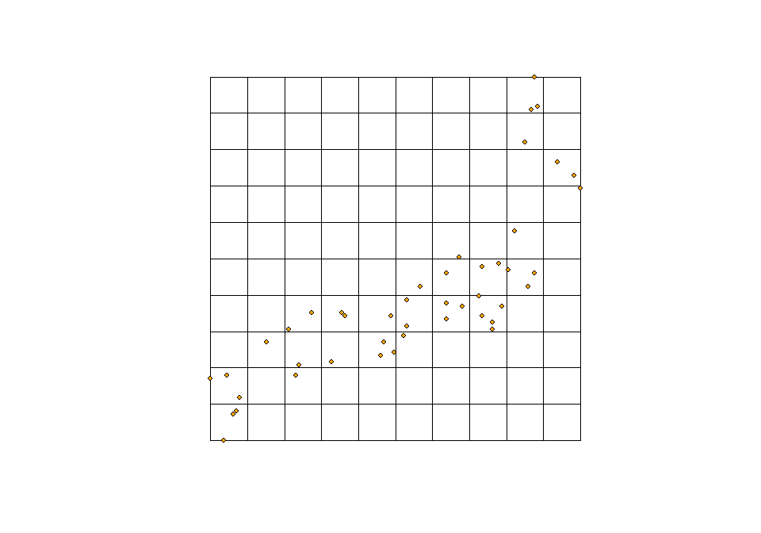

```r
plot(ESPDF)
points(Edata.loc,pch=21,bg="orange",cex=0.9)
```

Next, we must make a neighbor matrix of this meshes by the following code:

```r
makeNeighbor("filePath", lat, lon, northPole, southPole, loop)
```

The argument of “filePath” requires a path of the neighbor matrix file. Since vignette cannot export a file, we here use pre-made data instead:

```r
neighbor<-system.file("extdata","neighbor.txt",package="alleleAtlas")
```

Then, let’s check the result of interpolation using this mesh.

```r
Eid.samples<-getIDsamples(Edata.loc,ESPDF,TRUE)
EdataMatrix<-makeDataMatrix(Edata,Ealternative,EalleleSequence,Eid.samples,lat*lon)
randomModel<-"besagproper"
Emodels<-calcCAR(EalleleSequence,randomModel,neighbor,EdataMatrix)
EfreqCAR<-getMeanQt(Emodels,EdataMatrix)
plotAllFreq(ESPDF,EfreqCAR[[1]],size=24)
```

[interactive chart not shown]

You can compare the above result with the sample frequencies by the following command:

```r
Edata.prob<-makeSampleFreq(EdataMatrix,ESPDF)
plotAllFreq(ESPDF,Edata.prob,size=24)
```

[interactive chart not shown]

Next, use of user-made meshes will be explained. A way to make an shape file of meshes is explained the original article. Please load a shape file by the following code:

```r
shapesf<-read_sf("filePath")
```

Instead of this, an example data is used here:

```r
shapesf<-read_sf(system.file("extdata","fagusLGMmesh.shp",package="alleleAtlas"))
```

The later process is not so different from the previous analysis:

```r
ESPDF<-sf2SPDF(shapesf)
nb<-poly2nb(shapesf,queen=TRUE,snap=1,useC=T)
Egraph<-nb2mat(nb,style="B")
Eid.samples<-getIDsamples(Edata.loc,ESPDF,TRUE)
EdataMatrix<-makeDataMatrix(Edata,Ealternative,EalleleSequence,Eid.samples,length(ESPDF))
Emodels<-calcCAR(EalleleSequence,randomModel,Egraph,EdataMatrix)
EfreqCAR<-getMeanQt(Emodels,EdataMatrix)
plotAllFreq(ESPDF,EfreqCAR[[2]],size=24)
```

[interactive chart not shown]

### 3.3 Test continuous inference

In continuous inference, the package uses a user-made shape file which defines the study area. This file is not divided into meshes like the previous file. You can prepare this file by dissolving the meshes into a single polygon. You can load your own shape file by the following code:

```r
shapesf<-read_sf("filePath")
```

Instead of this, an example data is used here:

```r
shapesf<-read_sf(system.file("extdata","fagusLGMmesh_dissolved.shp",package="alleleAtlas"))
```

Then, triangular meshes are created on the area of the shape file. This meshes decides the result and calculation time. Therefore, please try several combinations of max.edge and cutoff.

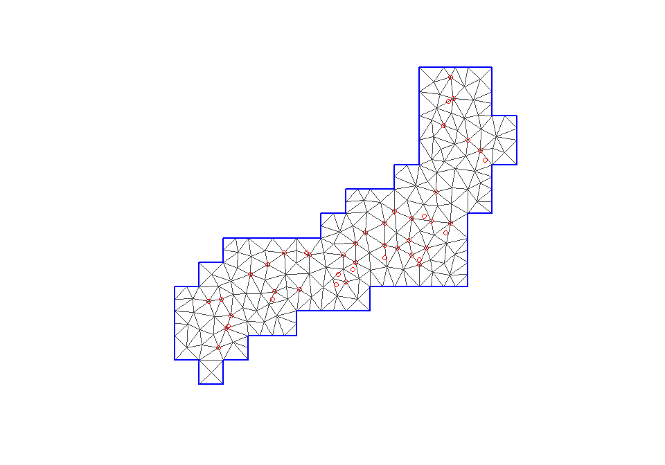

```r
bound<-inla.sp2segment(shapesf)
mesh<-fm_mesh_2d(loc=Edata.loc,boundary=bound,max.edge=c(1),cutoff=0.5)
plot(mesh)
points(Edata.loc,col="red")
```

Finally, calculate the interpolation using the triangular meshes.

```r
proj<-inla.mesh.projector(mesh,dims=c(20,20))
estimate.loc<-polygons2centerpoints(ESPDF)
Emodels<-calcSPDE(Ealternative,EdataMatrix,mesh=mesh,data.loc=estimate.loc)
prob<-getMeanQtSPDE(Emodels,mesh,estimate.loc)
plotAllFreq(ESPDF,prob[[2]],dimx=15,dimy=15,size=24)
```

[interactive chart not shown]

## 4 Cross validation

The result of interpolation changes depending on the meshes, models and posterior statistics (posterior mean or median). Then, how can we judge which is the best estimation? One way to do it is to use cross validation.

This package has functions to conduct leave-one-out cross validation (LOOCV), and the functions provide three statistics: total variation distance (TV), logloss and negative log likelihood (NLL). They slightly differ, but smaller value is better for all of them. Logloss and NLL cannot be calculated when the leave-one-out location includes location-specific allele. On the other hand, NLL is theoretically concordant with model selection. Therefore, I personally recommend to use NLL for model selection within a method and to use TV for comparison among different methods, posterior mean and median.

Following code conducts LOOCV for the discrete inference using two models: besag and besag2. The other two models, besagproper and besagproper2, also can be the candidates, but they are omitted here. Please note that LOOCV takes much longer time for calculation than one-time interpolation.

```r
Edata.count<-makeSampleAlleleCount(EdataMatrix,ESPDF)
randomModels<-c("besag","besag2")

NLLQtCAR<-vector("numeric",length(randomModels))
NLLMnCAR<-vector("numeric",length(randomModels))
lossQtCAR<-vector("numeric",length(randomModels))
lossMnCAR<-vector("numeric",length(randomModels))
TVQtCAR<-vector("numeric",length(randomModels))
TVMnCAR<-vector("numeric",length(randomModels))

for(j in 1:length(randomModels))
{
    print(randomModels[j])
    locQtNLL<-rep(NA,length(ESPDF))
    locMnNLL<-rep(NA,length(ESPDF))
    locQtLoss<-rep(NA,length(ESPDF))
    locMnLoss<-rep(NA,length(ESPDF))
    locQtTV<-rep(NA,length(ESPDF))
    locMnTV<-rep(NA,length(ESPDF))
    for(i in 1:length(ESPDF))
    {
        print(paste0("mesh ",i,"/",length(ESPDF)))
        newData<-leaveOneOutMesh(i,Edata,Eid.samples)
        if(length(newData)==length(data))
        {
            next
        }
        temp<-processInput(newData)
        data.loc<-temp[[1]]
        alleleCount<-temp[[2]]
        alleleSequence<-temp[[3]]
        alternative<-temp[[4]]
        id.samples<-getIDsamples(data.loc,ESPDF,TRUE)
        dataMatrix<-makeDataMatrix(newData,alternative,alleleSequence,id.samples,length(ESPDF))
        models<-calcCAR(alleleSequence,randomModels[j],Egraph,dataMatrix)
        qt<-getMeanQt(models,dataMatrix)
        #add 0 for non-observed allele frequencies
        allFreqMn<-matrix(0,nrow=nrow(qt[[1]]),ncol=length(EalleleSequence))
        allFreqQt<-matrix(0,nrow=nrow(qt[[2]]),ncol=length(EalleleSequence))
        for(r in 1:nrow(qt[[1]]))
        {
            allFreqMn[r,]<-padProb(qt[[1]][r,],alleleSequence,EalleleSequence)
            allFreqQt[r,]<-padProb(qt[[2]][r,],alleleSequence,EalleleSequence)
            allFreqQt[r,]<-allFreqQt[r,]/sum(allFreqQt[r,])
        }
        locQtNLL[i]<-validateFrequency(i,allFreqQt,Edata.count,"logloss")
        locMnNLL[i]<-validateFrequency(i,allFreqMn,Edata.count,"logloss")
        locQtLoss[i]<-validateFrequency(i,allFreqQt,Edata.prob,"logloss")
        locMnLoss[i]<-validateFrequency(i,allFreqMn,Edata.prob,"logloss")
        locQtTV[i]<-validateFrequency(i,allFreqQt,Edata.prob,"TV")
        locMnTV[i]<-validateFrequency(i,allFreqMn,Edata.prob,"TV")
    }
    NLLQtCAR[j]<-mean(locQtNLL,na.rm=TRUE)
    NLLMnCAR[j]<-mean(locMnNLL,na.rm=TRUE)
    lossQtCAR[j]<-mean(locQtLoss,na.rm=TRUE)
    lossMnCAR[j]<-mean(locMnLoss,na.rm=TRUE)
    TVQtCAR[j]<-mean(locQtTV,na.rm=TRUE)
    TVMnCAR[j]<-mean(locMnTV,na.rm=TRUE)
}
```

```
#> [1] "besag"
#> [1] "mesh 1/68"
#> [1] "mesh 2/68"
#> [1] "mesh 3/68"
#> [1] "mesh 4/68"
#> [1] "mesh 5/68"
#> [1] "mesh 6/68"
#> [1] "mesh 7/68"
#> [1] "mesh 8/68"
#> [1] "mesh 9/68"
#> [1] "mesh 10/68"
#> [1] "mesh 11/68"
#> [1] "mesh 12/68"
#> [1] "mesh 13/68"
#> [1] "mesh 14/68"
```

[output cut: 123 more lines]

```r
#meanLossCAR
bestModelQt<-randomModels[grep(min(NLLQtCAR),NLLQtCAR)]
bestModelMn<-randomModels[grep(min(NLLMnCAR),NLLMnCAR)]

qtModel<-calcCAR(Ealternative,bestModelQt,Egraph,EdataMatrix)
Eqt<-getMeanQt(qtModel,EdataMatrix)
mnModel<-calcCAR(Ealternative,bestModelMn,Egraph,EdataMatrix)
Emn<-getMeanQt(mnModel,EdataMatrix)

CARresultQt<-Eqt[[2]]
CARresultMn<-Emn[[1]]

#make CARresultQt summed up to 1
for(j in 1:length(ESPDF))
{
    locFreqSum<-sum(CARresultQt[j,])
    CARresultQt[j,]<-CARresultQt[j,]/locFreqSum
}
plotAllFreq(ESPDF,CARresultQt,size=24)
```

[interactive chart not shown]

```r
plotAllFreq(ESPDF,CARresultMn,size=24)
```

[interactive chart not shown]

```r
bestNLLQtCAR<-NLLQtCAR[grep(min(lossQtCAR),lossQtCAR)]
bestNLLMnCAR<-NLLMnCAR[grep(min(lossMnCAR),lossMnCAR)]
bestLossQtCAR<-lossQtCAR[grep(min(lossQtCAR),lossQtCAR)]
bestLossMnCAR<-lossMnCAR[grep(min(lossMnCAR),lossMnCAR)]
bestTVQtCAR<-TVQtCAR[grep(min(lossQtCAR),lossQtCAR)]
bestTVMnCAR<-TVMnCAR[grep(min(lossMnCAR),lossMnCAR)]
```

Likewise, following codes conduct LOOCV for the continuous method and inverse distance weighting which is conducted by phylin package.

```r
NLLQtSPDE<-0
NLLMnSPDE<-0
lossQtSPDE<-0
lossMnSPDE<-0
TVQtSPDE<-0
TVMnSPDE<-0

NLLQtSPDEpc<-0
NLLMnSPDEpc<-0
lossQtSPDEpc<-0
lossMnSPDEpc<-0
TVQtSPDEpc<-0
TVMnSPDEpc<-0

locQtNLL<-rep(NA,length(ESPDF))
locMnNLL<-rep(NA,length(ESPDF))
locQtLoss<-rep(NA,length(ESPDF))
locMnLoss<-rep(NA,length(ESPDF))
locQtTV<-rep(NA,length(ESPDF))
locMnTV<-rep(NA,length(ESPDF))
locQtNLLpc<-rep(NA,length(ESPDF))
locMnNLLpc<-rep(NA,length(ESPDF))
locQtLosspc<-rep(NA,length(ESPDF))
locMnLosspc<-rep(NA,length(ESPDF))
locQtTVpc<-rep(NA,length(ESPDF))
locMnTVpc<-rep(NA,length(ESPDF))

for(i in 1:length(ESPDF))
{
    print(paste0("mesh ",i,"/",length(ESPDF)))
    newData<-leaveOneOutMesh(i,Edata,Eid.samples)
    if(length(newData)==length(data))
    {
        next
    }
    temp<-processInput(newData)
    data.loc<-temp[[1]]
    alleleCount<-temp[[2]]
    alleleSequence<-temp[[3]]
    alternative<-temp[[4]]
    id.samples<-getIDsamples(data.loc,ESPDF,TRUE)
    dataMatrix<-makeDataMatrix(newData,alternative,alleleSequence,id.samples,length(ESPDF))
    model<-calcSPDE(alternative,dataMatrix,mesh=mesh,data.loc=estimate.loc,spdeType="matern")
    modelpc<-calcSPDE(alternative,dataMatrix,mesh=mesh,data.loc=estimate.loc,spdeType="pc")

    qt<-getMeanQtSPDE(model,mesh,estimate.loc)
    qtpc<-getMeanQtSPDE(modelpc,mesh,estimate.loc)
    #add 0 for non-observed allele frequencies
    allFreqMn<-matrix(0,nrow=nrow(qt[[1]]),ncol=length(EalleleSequence))
    allFreqQt<-matrix(0,nrow=nrow(qt[[2]]),ncol=length(EalleleSequence))
    allFreqMnpc<-matrix(0,nrow=nrow(qtpc[[1]]),ncol=length(EalleleSequence))
    allFreqQtpc<-matrix(0,nrow=nrow(qtpc[[2]]),ncol=length(EalleleSequence))
    for(r in 1:nrow(qt[[1]]))
    {
        allFreqMn[r,]<-padProb(qt[[1]][r,],alleleSequence,EalleleSequence)
        allFreqQt[r,]<-padProb(qt[[2]][r,],alleleSequence,EalleleSequence)
        allFreqMnpc[r,]<-padProb(qtpc[[1]][r,],alleleSequence,EalleleSequence)
        allFreqQtpc[r,]<-padProb(qtpc[[2]][r,],alleleSequence,EalleleSequence)
        allFreqQt[r,]<-allFreqQt[r,]/sum(allFreqQt[r,])
        allFreqQtpc[r,]<-allFreqQtpc[r,]/sum(allFreqQtpc[r,])
    }
    locQtNLL[i]<-validateFrequency(i,allFreqQt,Edata.count,"logloss")
    locMnNLL[i]<-validateFrequency(i,allFreqMn,Edata.count,"logloss")
    locQtLoss[i]<-validateFrequency(i,allFreqQt,Edata.prob,"logloss")
    locMnLoss[i]<-validateFrequency(i,allFreqMn,Edata.prob,"logloss")
    locQtTV[i]<-validateFrequency(i,allFreqQt,Edata.prob,"TV")
    locMnTV[i]<-validateFrequency(i,allFreqMn,Edata.prob,"TV")
    locQtNLLpc[i]<-validateFrequency(i,allFreqQtpc,Edata.count,"logloss")
    locMnNLLpc[i]<-validateFrequency(i,allFreqMnpc,Edata.count,"logloss")
    locQtLosspc[i]<-validateFrequency(i,allFreqQtpc,Edata.prob,"logloss")
    locMnLosspc[i]<-validateFrequency(i,allFreqMnpc,Edata.prob,"logloss")
    locQtTVpc[i]<-validateFrequency(i,allFreqQtpc,Edata.prob,"TV")
    locMnTVpc[i]<-validateFrequency(i,allFreqMnpc,Edata.prob,"TV")
}
NLLQtSPDE<-mean(locQtNLL,na.rm=TRUE)
NLLMnSPDE<-mean(locMnNLL,na.rm=TRUE)
lossQtSPDE<-mean(locQtLoss,na.rm=TRUE)
lossMnSPDE<-mean(locMnLoss,na.rm=TRUE)
TVQtSPDE<-mean(locQtTV,na.rm=TRUE)
TVMnSPDE<-mean(locMnTV,na.rm=TRUE)
NLLQtSPDEpc<-mean(locQtNLLpc,na.rm=TRUE)
NLLMnSPDEpc<-mean(locMnNLLpc,na.rm=TRUE)
lossQtSPDEpc<-mean(locQtLosspc,na.rm=TRUE)
lossMnSPDEpc<-mean(locMnLosspc,na.rm=TRUE)
TVQtSPDEpc<-mean(locQtTVpc,na.rm=TRUE)
TVMnSPDEpc<-mean(locMnTVpc,na.rm=TRUE)
```

```r
powers<-c(1,2,3,4,5,6,7,8,9,10)
NLLIDW<-vector("numeric",length(powers))
lossIDW<-vector("numeric",length(powers))
TVIDW<-vector("numeric",length(powers))
for(j in 1:length(powers))
{
print(paste0("power: ",powers[j]))
    locNLL<-rep(NA,length(ESPDF))
    locLoss<-rep(NA,length(ESPDF))
    locTV<-rep(NA,length(ESPDF))
    for(i in 1:length(ESPDF))
    {
        newData<-leaveOneOutMesh(i,Edata,Eid.samples)
        if(length(newData)==length(data))
        {
            next
        }
        temp<-processInput(newData)
        data.loc<-temp[[1]]
        alleleCount<-temp[[2]]
        alleleSequence<-temp[[3]]
        alternative<-temp[[4]]
        alleleSPDF<-getAlleleSPDF(newData)
        IDWresult<-matrix(0,ncol=alternative,nrow=length(grid[,1]))
        for(k in 1:alternative)
        {
            IDWresult[,k]<-eval(parse(text=paste0("phylin::idw(alleleSPDF$X",k,",p=powers[",j,"],data.loc,grid,N=45)[,1]")))
        }
        #add 0 for non-observed allele frequencies
        allFreq<-matrix(0,nrow=nrow(IDWresult),ncol=length(EalleleSequence))
        for(r in 1:nrow(IDWresult))
        {
            allFreq[r,]<-padProb(IDWresult[r,],alleleSequence,EalleleSequence)
        }
        locNLL[i]<-validateFrequency(i,allFreq,Edata.count,"logloss")
        locLoss[i]<-validateFrequency(i,allFreq,Edata.prob,"logloss")
        locTV[i]<-validateFrequency(i,allFreq,Edata.prob,"TV")
    }
    NLLIDW[j]<-mean(locNLL,na.rm=TRUE)
    lossIDW[j]<-mean(locLoss,na.rm=TRUE)
    TVIDW[j]<-mean(locTV,na.rm=TRUE)
}

#power which gives minimum logloss
bestPower<-powers[grep(min(NLLIDW),NLLIDW)]

EalleleSPDF<-getPopulationAlleleSPDF(Edata,Edata)
IDWresult<-matrix(0,ncol=Ealternative,nrow=length(grid[,1]))
for(i in 1:Ealternative)
{
    IDWresult[,i]<-eval(parse(text=paste0("phylin::idw(EalleleSPDF$X",i,",p=bestPower,Edata.loc,grid,N=45)[,1]")))
}
#show result
plotAllFreq(ESPDF,IDWresult,size=24)

#obtain logloss for the best parameter
bestNLLIDW<-NLLIDW[bestPower]
bestLossIDW<-lossIDW[bestPower]
bestTVIDW<-TVIDW[bestPower]
```

## 5 The other functions

This package also has functions to calculate credible intervals, nucleotide diversity and expected heterozygosity from the interpolated result and plot data on a map. The next codes plot the frequency of the first allele type, its 95% credible interval and expected heterozygosity from the interpolation result. These can be plotted for the discrete results by changing mesh to ESPDF in this example codes.

```r
plotDatum(ESPDF,EfreqCAR[[1]][,1],"allele1")
```

[interactive chart not shown]

```r
plotDatum(ESPDF,EfreqCAR[[2]][,1],"allele1LowerCI")
```

[interactive chart not shown]

```r
plotDatum(ESPDF,EfreqCAR[[3]][,1],"allele1HigherCI")
```

[interactive chart not shown]

```r
plotDatum(ESPDF,calcExpectedHeterozygosity(EfreqCAR[[1]]),"exheterozygosity")
```

[interactive chart not shown]